# Análisis de la tasa de conservación de codones y pares de codones

##### Autor: Facundo Martínez

En esta notebook se procederá a realizar el análisis de la información obtenida mediante el algoritmo de Python.

## 1. Tasa de conservación

### 1.1 Carga de los datos

Comienzo por setear el directorio de trabajo e importar los datasets a utilizar:

```r
setwd("/home/usuario/Documents/GitHub/Conservacion-de-codones-raros/dataframes")
datos_codones <- read.csv("data3_facundo.csv")
datos_bicodones <- read.csv("data6_facundo.csv")
```

### 1.2 Cálculo de la tasa de conservación para codones

Una vez importados los datasets, procedo a calcular la tasa de conservación de cada codón:

```r
datos_codones$tasaConservacion <- datos_codones$conservacion / datos_codones$referencia
```

### 1.3 Establecimiento de codones raros

Deseo establecer cuáles de los codones presentes en la lista son raros. Para ello me he basado en el codon usage de Drosophila melanogaster:

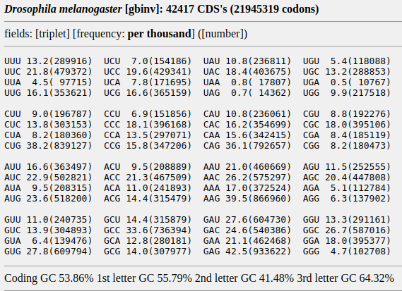

Cliqueando la imagen se podrá acceder a la fuente. He clasificado como codones raros a aquellos dentro de cada grupo que poseen el menor uso, además de hacer una distinción entre codones óptimos (los de mayor uso) y subóptimos (los de uso intermedio). Para el siguiente análisis he omitido los codones subóptimos en la lista de codones raros, centrándome así en aquellos que poseen el menor uso dentro de cada grupo de péptidos.

```r
codones_raros <- c("TTT", "TTA", "CTT", "CTC", "CTA", "ATT", "ATA", "GTT", "GTC", "GTA", "TCT",
                   "TCA", "CCT", "ACT", "ACA", "ACG", "GCT", "GCA", "GCG", "TAT", "CAT", "CAA",
                   "AAT", "AAA", "GAA", "TGT", "CGT", "CGA", "CGG", "GCT", "GGG")

# Establecer codones raros
# Raro: TRUE, no raro: FALSE
datos_codones$esRaro <- logical(length = 61)

for(i in codones_raros){
  for(j in datos_codones$codon){
    if(i==j){
      datos_codones[datos_codones$codon==j, 5] <- TRUE
    }
  }
}
```

### 1.4 Gráfico de las tasas de conservación para codones normales y raros

Habiendo establecido en el dataset cuáles codones son raros, procedo a realizar un gráfico para comparar visualmente las tasas de conservación entre codones raros y normales:

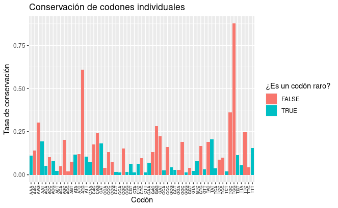

```r
library(ggplot2)
codones_barplot <- ggplot(datos_codones,
                          aes(   x = codon,
                                 y = tasaConservacion,
                              fill = esRaro)) +
                   geom_bar(stat = "identity") +
                   labs(    x = "Codón",
                            y = "Tasa de conservación",
                        title = "Conservación de codones individuales") +
                   guides(fill = guide_legend(title = "¿Es un codón raro?")) +
                   theme(axis.text.x = element_text(angle = 90,
                                                    hjust = 1,
                                                    vjust = 0.5,
                                                    size = 6,
                                                    face = "bold"))

codones_barplot
```

Puede verse que hay dos codones normales que poseen una alta tasa de conservación, estos codones corresponden a los aminoácidos metionina y triptofano. Esto podría deberse a que, por un lado, la metionina es un codón que determina el inicio de la traducción del mRNA y, en el caso del triptofano, a que es el único aminoácido que es especificado por un solo tipo de codón.

### 1.5 Cálculo de la tasa de conservación para pares de codones

Procedo a realizar el mismo análisis, pero para pares de codones. En el siguiente bloque se determinarán las tasas de conservación de cada par codónico, los codones constituyentes del par (en columnas separadas), la tasa de conservación de cada codón constituyente (a partir de `datos_codones`), el producto de las tasas de cada codón constituyente del par (lo cual nos brinda la tasa teórica de conservación del par debida puramente al azar), y cuáles de los pares de codones son pares inhibitorios (es decir, pares de codones raros):

```r
datos_bicodones$tasaConservacion <- datos_bicodones$conservacion / datos_bicodones$referencia

datos_bicodones$esRaro <- c(length = 3721)
datos_bicodones$primerCodon <- character(length = 3721)
datos_bicodones$segundoCodon <- character(length = 3721)

iterador = 1
for(i in datos_bicodones$bicodon){
  vector_codones <- strsplit(i, "(?<=.{3})", perl = TRUE)[[1]]
  datos_bicodones[iterador, 6] <- vector_codones[1]
  datos_bicodones[iterador, 7] <- vector_codones[2]
  iterador = iterador + 1
}

# Tasas individuales de cada codon
datos_bicodones$tasaCodon1 <- numeric(length = 3721)
datos_bicodones$tasaCodon2 <- numeric(length = 3721)

for(i in datos_codones$codon){
  for(j in datos_bicodones$primerCodon){
  if(i == j){
    datos_bicodones[datos_bicodones$primerCodon == i, 8] <- datos_codones[datos_codones$codon == i, 4]
    }
  }
}

for(j in datos_codones$codon){
  for(k in datos_bicodones$segundoCodon){
    if(j == k){
      datos_bicodones[datos_bicodones$segundoCodon == j, 9] <- datos_codones[datos_codones$codon == j, 4]
    }
  }
}

# Cálculo del producto de tasas
datos_bicodones$productoDeTasas <- datos_bicodones$tasaCodon1 * datos_bicodones$tasaCodon2

# Determinación de pares de codones inhibitorios
datos_bicodones$cod1Bool <- logical(length = 3721)
datos_bicodones$cod2Bool <- logical(length = 3721)

for(i in codones_raros){
  for(j in datos_bicodones$primerCodon){
    if(i == j){
      datos_bicodones[datos_bicodones$primerCodon == j, 11] <- TRUE
    }
  }
}

for(i in codones_raros){
  for(k in datos_bicodones$segundoCodon){
    if(i == k){
      datos_bicodones[datos_bicodones$segundoCodon == k, 12] <- TRUE
    }
  }
}

datos_bicodones$esRaro <- datos_bicodones$cod1Bool * datos_bicodones$cod2Bool # Raro: 1, no raro: 0
```

### 1.6 Gráfico de la tasa de conservación real vs. teórica

Graficamos la tasa de conservación en función del producto de tasas. Si la tasa de conservación de cada par fuese igual a la predicha por el azar, deberíamos ver muchos puntos distribuidos en una línea recta:

```r
modelo <- ggplot(data = datos_bicodones,
                 aes(   x = productoDeTasas,
                        y = tasaConservacion,
                        color = factor(esRaro))) +
          geom_point(stat = "identity",
                     size = 1)

modelo
```

[output not shown]

```r
bicodones_raros <- subset(datos_bicodones, esRaro == 1)

plot_pares_inhibitorios <- ggplot(data = bicodones_raros,
                                  aes(   x = productoDeTasas,
                                         y = tasaConservacion,
                                     label = bicodon)) +
                          geom_rect(aes(xmin = 0, xmax = 0.05,
                                        ymin = 0, ymax = 0.05),
                                    fill = "#69b3a2",
                                    alpha = 0.2) +
                           geom_point(color = "blueviolet") +
                           xlim(0, 0.05) +
                           ylim(0, 0.2) +
                           geom_hline(yintercept = 0.05, linetype = "dotdash") +
                           geom_vline(xintercept = 0.05, linetype = "dotdash") +
                           geom_abline(aes(intercept = 0,
                                               slope = 1)) +
                           labs(x = "Producto de tasas de conservación de codones constituyentes",
                                y = "Tasa de conservación real del bicodón raro",
                                title = "Tasa real vs. tasa predicha para bicodones raros")

plot_pares_inhibitorios
```

[output not shown]

### 1.7 Normalización de la tasa de conservación

Para visualizar mejor esto, procedo a realizar una normalización de la tasa de conservación, dividiendo la tasa real sobre la predicha. Posteriormente grafico el resultado:

```r
datos_bicodones$tasaRealSobrePredicha <- datos_bicodones$tasaConservacion / datos_bicodones$productoDeTasas
bicodones_raros <- subset(datos_bicodones, esRaro == 1)
bicodones_raros_conservados <- subset(bicodones_raros, tasaRealSobrePredicha > 50)

plot_pares_inhibitorios_conservados <- ggplot(data = bicodones_raros_conservados,
                                              aes(   x = productoDeTasas,
                                                     y = tasaConservacion,
                                                     label = bicodon)) +
                                       geom_point(color = "blueviolet") +
                                       xlim(0, 0.0015) +
                                       ylim(0, 0.2) +
                                       labs(x = "Producto de tasas de conservación de codones constituyentes",
                                            y = "Tasa de conservación real del bicodón raro",
                                            title = "Pares de codones raros conservados")  +
                                       geom_text(aes(label = bicodon,
                                                     hjust = 0,
                                                     vjust = 0),
                                                 size = 3,
                                                 check_overlap = TRUE)

plot_pares_inhibitorios_conservados
bicodones_raros_conservados$bicodon
```

[output not shown]

¿Qué sucede con los bicodones normales?

```r
bicodones_normales <- subset(datos_bicodones, esRaro == 0)
bicodones_normales_conservados <- subset(bicodones_normales, tasaRealSobrePredicha > 50)
bicodones_normales_conservados$bicodon
```

[output not shown]

## 2. Modelo de ajuste lineal

Para ver el grado de ajuste lineal, se realizó el siguiente modelo graficando la tasa real de conservación de pares de codones en función de la tasa teórica de conservación, tomando como ordenada al origen `y(0) = 0`:

```r
modelo_lineal <- lm(tasaConservacion ~ 0 + productoDeTasas, data = datos_bicodones)

summary(modelo_lineal)
plot(modelo_lineal)
```

[output not shown]

## 3. Z-score Distribution Plot

### 3.1 Ecuación del z-score

Para calcular el z-score se utiliza la siguiente ecuación:

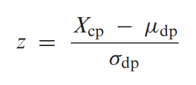

Donde Xcp representa la tasa normalizada de conservación del par de codones, udp depresenta la media normalizada de la tasa de conservación de la familia de pares de codones que codifican un mismo dipéptido, y sigmadp es el desvío estándar para la familia de dipéptidos. Esta ecuación asume que la distribución de los datos es normal. El z-score nos da una idea de cuán alejados están ciertos pares de codones de otros.

### 3.2 Cálculo de las medias y desvíos para dipéptidos

Para medir la distancia de una muestra con respecto a su media en unidades de desvío estándar, es necesario hacer un cálculo del z-score a partir del logaritmo decimal de las tasas normalizadas de conservación para cada grupo de dipéptidos.

```r
datos <- read.csv("datos_zscore.csv")
```

### 3.3 Z-score para cada par de codones

Usando las medias y desvíos calculados anteriormente, procedo a calcular el z-score:

```r
analisis_bicodones_V2 <- read.csv("analisis_bicodones_V2.csv")
analisis_bicodones_V2$zscore <- numeric(length = 3721)

for (i in datos_zscore$dipeptido){
  u = datos_zscore[datos_zscore$dipeptido == i, 2]
  sdev = datos_zscore[datos_zscore$dipeptido == i, 3]
  for (j in analisis_bicodones_V2$dipeptido){
    if (i == j){
      x <- analisis_bicodones_V2[analisis_bicodones_V2$dipeptido == j, 18]
      z = (x - u)/sdev
      analisis_bicodones_V2[analisis_bicodones_V2$dipeptido == j, 19] <- z
    }
  }
}
```

### 3.4 Z-scores visualizados en histograma

Ya calculados los z-scores en el paso anterior, procedo a graficarlos:

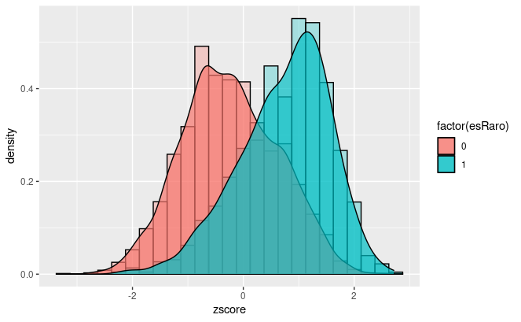

```r
histograma <- ggplot(analisis_bicodones_V2,
                     aes(x = zscore, fill = factor(esRaro))) +
              geom_histogram(binwidth = 0.25,
                             colour = 'black',
                             position = "identity",
                             alpha = 0.3, aes(y = ..density..)) +
              geom_density(alpha = 0.7)
histograma
```

## 4. Contenido de GC

A fines investigativos se desea conocer si existe una preferencia por GC en los pares de codones. Para eso se ejecutan las siguientes líneas de código en consola:

```r
analisis_bicodones_V2[(analisis_bicodones_V2$esRaro == 1) && analisis_bicodones_V2$tasaRealSobrePredicha > 50, 17]
```

```
factor(0)
400 Levels: Ala-Ala Ala-Arg Ala-Asn Ala-Asp Ala-Cys Ala-Gln Ala-Glu Ala-Gly Ala-His Ala-Ile Ala-Leu Ala-Lys Ala-Met Ala-Phe ... Val-Val
```

```r
bicodones_raros_conservados$bicodon
```

```
 [1] TTACTT CTACTA CTACCT CTAGTC CTTGGG CCTGTA CCTGGG CGGCCT CGGGGG GTAACT GTATTA GTACTA GTACTT GTACCT GTTCCT GGGACT GGGCTT GGGGGG
3721 Levels: AAAAAA AAAAAC AAAAAG AAAAAT AAAACA AAAACC AAAACG AAAACT AAAAGA AAAAGC AAAAGG AAAAGT AAAATA AAAATC AAAATG AAAATT AAACAA ... TTTTTT
```